# 20212_M2.875_PEC2-Solucion

[figure not shown]

M2.875 · Deep Learning · PEC2

2021-2 · Máster universitario en Ciencia de datos (Data science)

Estudios de Informática, Multimedia y Telecomunicación

# PEC2: Redes Neuronales Convolucionales con KERAS

A lo largo de esta práctica vamos a implementar varios modelos de redes neuronales para clasificar las imágenes de la base de datos [CIFAR10](https://www.cs.toronto.edu/~kriz/cifar.html).

La base de datos CIFAR10 está formada por imágenes en color de dimensiones 32x32 píxels que pertenecen a 10 clases:

- airplane (label 0)
- automobile (label 1)
- bird (label 2)
- cat (label 3)
- deer (label 4)
- dog (label 5)
- frog (label 6)
- horse (label 7)
- ship (label 8)
- truck (label 9)

Esta base de datos está compuesta de 60.000 registros que se dividen a su vez en 2 conjuntos: 50.000 imágenes para el conjunto de entrenamiento y 10.000 imágenes para el conjunto de test.

En el ejercicio llevaremos a cabo la tarea de construir varios modelos con el objetivo de conseguir la mayor precisión al realizar la clasificación de las imágenes. Para ello implementaremos y analizaremos los siguientes modelos:

1. Una red neuronal artificial completamente conectada
2. Una red neuronal convolucional de una capa
3. Una red neuronal convolucional profunda

 En todos los casos se utilizará la librería Keras con Tensorflow para la implementación del modelo, la compilación y el entrenamiento.

Finalmente, realizaremos una predicción de las imágenes con el mejor modelo implementado.

 **Importante: Cada uno de los ejercicios puede suponer varios minutos de ejecución, por lo que la entrega debe hacerse en formato notebook y en formato html donde se vea el código y los resultados y comentarios de cada ejercicio. Para exportar el notebook a html puede hacerse desde el menú File $\to$ Download as $\to$ HTML.**

## 1. Descarga, análisis y pre-procesado de los datos (1,5 puntos)

### 1.1 Descarga de datos

Empezamos importando algunos paquetes para la realización de la práctica y procedemos a descargar el dataset.

```python
import numpy as np
from tensorflow import keras
from keras.datasets import cifar10
from tensorflow.keras.utils import to_categorical
from keras.models import Sequential
from keras.layers import Dense, Conv2D, Flatten, Activation, Dropout, MaxPooling2D
from tensorflow.keras.optimizers import Adam, SGD, Adadelta, Adagrad
import matplotlib.pyplot as plt
import time
from sklearn.metrics import confusion_matrix, classification_report
import seaborn as sns
```

```python
# Descarga el dataset CIFAR10 y hace la partición train/test
(X_train, y_train), (X_test, y_test) = cifar10.load_data()
```

```
Downloading data from https://www.cs.toronto.edu/~kriz/cifar-10-python.tar.gz
```

### 1.2 Análisis de los datos

**Ejercicio [0,5 pts.]:** Representar la dimensión de las variables X_train, y_train, X_test e y_test. Mostrar las imágenes de los primeros 10 registros del conjunto X_train junto con sus etiquetas en formato texto. **Nota**: Al ser las imágenes de pequeño tamaño (32x32) se recomienda escalarlas a la hora de representarlas.

```python
# Análisis del conjunto de datos descargado

print("Tamaño de los datos de train: X = {}, y = {}".format(X_train.shape, y_train.shape))
print("Tamaño de los datos de test : X = {}, y = {}".format(X_test.shape, y_test.shape))
```

```
Tamaño de los datos de train: X = (50000, 32, 32, 3), y = (50000, 1)
Tamaño de los datos de test : X = (10000, 32, 32, 3), y = (10000, 1)
```

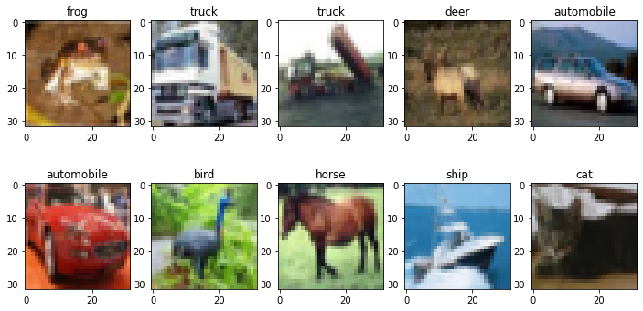

```python
labels = ['airplane', 'automobile', 'bird', 'cat', 'deer', 'dog', 'frog', 'horse', 'ship', 'truck']

# Mostramos las primeras 10 imágenes de X_train
n_cols = 5
n_rows = 2
fig, axes = plt.subplots(ncols=n_cols, nrows=n_rows, figsize=(12, 6))
index = 0
for i in range(n_rows):
    for j in range(n_cols):
        axes[i,j].set_title(labels[y_train[index][0]])
        axes[i,j].imshow(X_train[index])
        index += 1
plt.show()
```

### 1.3 Pre-procesado de datos

Dado que las imágenes están en color, vamos a convertirlas a escala de grises para realizar las primeras clasificaciones. Para ello utilizaremos la función `cvtColor` del paquete [OpenCV](https://pypi.org/project/opencv-python/) (cv2)

```python
import cv2

# Convierte X_train y X_test a escala de grises
X_train_grey = np.array([cv2.cvtColor(image, cv2.COLOR_BGR2GRAY) for image in X_train])
X_test_grey = np.array([cv2.cvtColor(image, cv2.COLOR_BGR2GRAY) for image in X_test])
```

**Ejercicio [0,25 pts.]:** Representar la dimensión de las variables X_train_grey y X_test_grey. Mostrar las imágenes de los primeros 10 registros del conjunto X_train_grey junto con sus etiquetas en formato texto.

```
Tamaño de los datos de train: X = (50000, 32, 32)
Tamaño de los datos de test : X = (10000, 32, 32)
```

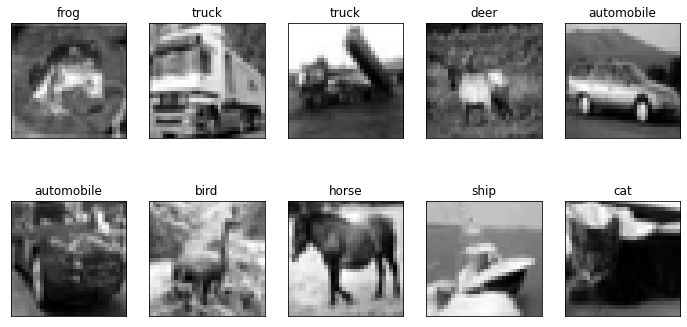

```python
# Análisis del conjunto de datos descargado
print("Tamaño de los datos de train: X = {}".format(X_train_grey.shape))
print("Tamaño de los datos de test : X = {}".format(X_test_grey.shape))

# Representamos las 10 primeras imágenes de X_train_grey
fig, axes = plt.subplots(ncols=n_cols, nrows=n_rows, figsize=(12, 6))
index = 0
for i in range(n_rows):
    for j in range(n_cols):
        axes[i,j].set_title(labels[y_train[index][0]])
        axes[i,j].imshow(X_train_grey[index], cmap='gray')
        axes[i,j].get_xaxis().set_visible(False)
        axes[i,j].get_yaxis().set_visible(False)
        index += 1
plt.show()
```

El primer paso para entrenar una red neuronal consiste en pre-procesar los datos de entrenamiento y test para que cuadren con el formato esperado por las entradas y salidas de la red neuronal.

Empezaremos normalizando los datos de entrada para que estén en el rango [0,1] ya que, como podemos ver a continuación, se trata de valores enteros entre 0 y 255.

```python
print("Los valores del primer registro del test son: {}".format(X_train_grey[0]))
```

```
Los valores del primer registro del test son: [[ 62  45  47 ... 128 121 120]
 [ 20   0   7 ...  82  77  82]
 [ 23   6  24 ...  78  78  68]
 ...
 [152 123 125 ... 117  27  32]
 [131 104 115 ... 136  58  51]
 [139 123 130 ... 174 112  90]]
```

```python
# Determinar valores mínimo y máximo
v_min = np.min(X_train_grey)
v_max = np.max(X_train_grey)
print("Los valores mínimo y máximo son {} y {}.".format(v_min, v_max))
```

```
Los valores mínimo y máximo son 0 y 255.
```

**Ejercicio [0,5 pts.]:** Normalizar los datos de entrada a la red para que estén comprendidos en el rango [0,1]. Imprimir los datos del primer registro una vez se ha llevado a cabo la normalización y comprobar de nuevo los valores máximo y mínimo.

```python
X_train_grey = X_train_grey / 255.0
X_test_grey = X_test_grey / 255.0
```

```python
print("Los valores del primer registro del test son: {}".format(X_train_grey[0]))
```

```
Los valores del primer registro del test son: [[0.24313725 0.17647059 0.18431373 ... 0.50196078 0.4745098  0.47058824]
 [0.07843137 0.         0.02745098 ... 0.32156863 0.30196078 0.32156863]
 [0.09019608 0.02352941 0.09411765 ... 0.30588235 0.30588235 0.26666667]
 ...
 [0.59607843 0.48235294 0.49019608 ... 0.45882353 0.10588235 0.1254902 ]
 [0.51372549 0.40784314 0.45098039 ... 0.53333333 0.22745098 0.2       ]
 [0.54509804 0.48235294 0.50980392 ... 0.68235294 0.43921569 0.35294118]]
```

```python
v_min = np.min(X_train_grey)
v_max = np.max(X_train_grey)

print("Los valores mínimo y máximo son {} y {}.".format(v_min, v_max))
```

```
Los valores mínimo y máximo son 0.0 y 1.0.
```

**Ejercicio [0,25 pts.]:** Codificar los valores de las etiquetas de salida en un vector one-hot. Por ejemplo, el vector de salida para una imagen que contiene un 5 sería: [0., 0., 0., 0., 0., 1., 0., 0., 0., 0.]. Comprobar el resultado imprimiendo su dimensión y mostrando algún registro.

**Nota**: Se puede utilizar la función `to_categorical` de `tensorflow.keras.utils`.

```python
y_train = to_categorical(y_train)
y_test = to_categorical(y_test)
```

```python
print("Tamaño de las etiquetas de train: y = {}".format(y_train.shape))
print("Tamaño de las etiquetas de test : y = {}".format(y_test.shape))
```

```
Tamaño de las etiquetas de train: y = (50000, 10)
Tamaño de las etiquetas de test : y = (10000, 10)
```

```python
y_test[0]
```

```
array([0., 0., 0., 1., 0., 0., 0., 0., 0., 0.], dtype=float32)
```

## 2. Red Neuronal Artificial (ANN) completamente conectada [2,5 puntos]

A continuación implementaremos una red neuronal *feed-forward fully connected* y llevaremos a cabo el entrenamiento y test sobre el dataset CIFAR.

### 2.1 Pre-procesado de datos

Dado que en una red neuronal artificial las entradas son unidimensionales, lo primero que tenemos que hacer es redimensionar los datos de entrada (las imágenes) para convertirlos en arrays de una dimensión.

**Ejercicio [0,5 pts.]:** Modificar los conjuntos X_train_grey y X_test_grey para que sus registros sean arrays unidimensionales de dimensión 32x32 = 1024 datos. Comprobad el resultado imprimiendo las dimensiones de las variables.

```python
X_train_gflat = X_train_grey.reshape(50000, 1024)
X_test_gflat = X_test_grey.reshape(10000, 1024)

# análisis del conjunto de datos pre-procesado
print("Tamaño de los datos de train: x = {}".format(X_train_gflat.shape))
print("Tamaño de los datos de test : x = {}".format(X_test_gflat.shape))
```

```
Tamaño de los datos de train: x = (50000, 1024)
Tamaño de los datos de test : x = (10000, 1024)
```

### 2.2 Creación del modelo

Vamos a usar un modelo `Sequential` de Keras

**Ejercicio [2 pts.]:** Implementa el modelo de red neuronal artificial:

- Diseña la arquitectura para el modelo de clasificación con las siguientes características:
- 6 capas ocultas de 128 neuronas.
- 3 capas de Dropout del 20% (rate=0,2) intercaladas cada 2 capas densas.
- Función de activación de las capas intermedias: ReLU.
- 1 capa de salida con las dimensiones y función de activación adecuadas para realizar la clasificación.
- Imprime el modelo para ver el número de parámetros a entrenar.
- Compila el modelo con la función de pérdida más adecuada, el optimizador SGD, una velocidad de aprendizaje de 0.01, y la métrica Accuracy.
- Ajusta el modelo con 100 épocas y un tamaño del batch de 128. Mide el tiempo de entrenamiento.
- Muestra las gráficas de accuracy y loss. En cada gráfica debe visualizarse la curva de entrenamiento y la de validación. NOTA: Se recomienda hacer una función que imprima ambas gráficas para poder reutilizarla en próximos apartados.
- Realiza la evaluación del modelo para mostrar la pérdida y la precisión final.

```python
#Crear el modelo ANN
from keras.layers import Dropout

num_classes = 10
dratio = 0.2
H_DIM = 128

model = Sequential()
model.add(Dense(H_DIM,input_shape=(1024,)))
model.add(Activation('relu'))
for i in range(5):
    model.add(Dense(H_DIM))
    model.add(Activation('relu'))
    if i%2==0:
        model.add(Dropout(dratio))

model.add(Dense(10))
model.add(Activation('softmax'))

print(model.summary())
```

```
Model: "sequential"
_________________________________________________________________
 Layer (type)                Output Shape              Param #
=================================================================
 dense (Dense)               (None, 128)               131200

 activation (Activation)     (None, 128)               0

 dense_1 (Dense)             (None, 128)               16512

 activation_1 (Activation)   (None, 128)               0

 dropout (Dropout)           (None, 128)               0

 dense_2 (Dense)             (None, 128)               16512

 activation_2 (Activation)   (None, 128)               0

 dense_3 (Dense)             (None, 128)               16512

 activation_3 (Activation)   (None, 128)               0

 dropout_1 (Dropout)         (None, 128)               0

 dense_4 (Dense)             (None, 128)               16512

 activation_4 (Activation)   (None, 128)               0

 dense_5 (Dense)             (None, 128)               16512

 activation_5 (Activation)   (None, 128)               0

 dropout_2 (Dropout)         (None, 128)               0

 dense_6 (Dense)             (None, 10)                1290

 activation_6 (Activation)   (None, 10)                0

=================================================================
Total params: 215,050
Trainable params: 215,050
Non-trainable params: 0
_________________________________________________________________
None
```

```python
#Compile
lr = 0.01

optim = SGD(learning_rate=lr)
model.compile(loss='categorical_crossentropy',
              optimizer=optim,
              metrics=['accuracy'])
```

```python
# Entrenar el modelo
batch_size = 128
ann_epoch = 100
verbose = 2
t = time.time()
mfit_ann = model.fit(X_train_gflat, y_train,
                batch_size=batch_size, epochs=ann_epoch,
                verbose=verbose,validation_data=(X_test_gflat, y_test))
print ("Tiempo de entrenamiento: ",time.time() - t, "segundos.")
```

```
391/391 - 7s - loss: 2.2840 - accuracy: 0.1231 - val_loss: 2.2523 - val_accuracy: 0.1498 - 7s/epoch - 18ms/step
391/391 - 2s - loss: 2.2316 - accuracy: 0.1645 - val_loss: 2.1857 - val_accuracy: 0.1992 - 2s/epoch - 6ms/step
391/391 - 2s - loss: 2.1813 - accuracy: 0.1865 - val_loss: 2.1303 - val_accuracy: 0.2157 - 2s/epoch - 5ms/step
391/391 - 2s - loss: 2.1357 - accuracy: 0.2021 - val_loss: 2.0809 - val_accuracy: 0.2363 - 2s/epoch - 4ms/step
391/391 - 2s - loss: 2.0949 - accuracy: 0.2225 - val_loss: 2.0599 - val_accuracy: 0.2361 - 2s/epoch - 5ms/step
391/391 - 2s - loss: 2.0638 - accuracy: 0.2360 - val_loss: 2.0103 - val_accuracy: 0.2601 - 2s/epoch - 4ms/step
391/391 - 2s - loss: 2.0341 - accuracy: 0.2483 - val_loss: 1.9861 - val_accuracy: 0.2728 - 2s/epoch - 4ms/step
391/391 - 2s - loss: 2.0100 - accuracy: 0.2601 - val_loss: 1.9609 - val_accuracy: 0.2864 - 2s/epoch - 4ms/step
391/391 - 2s - loss: 1.9892 - accuracy: 0.2690 - val_loss: 1.9347 - val_accuracy: 0.2967 - 2s/epoch - 5ms/step
391/391 - 2s - loss: 1.9726 - accuracy: 0.2758 - val_loss: 1.9198 - val_accuracy: 0.3070 - 2s/epoch - 5ms/step
391/391 - 2s - loss: 1.9531 - accuracy: 0.2864 - val_loss: 1.8986 - val_accuracy: 0.3186 - 2s/epoch - 5ms/step
391/391 - 2s - loss: 1.9398 - accuracy: 0.2937 - val_loss: 1.8843 - val_accuracy: 0.3224 - 2s/epoch - 4ms/step
391/391 - 2s - loss: 1.9238 - accuracy: 0.2992 - val_loss: 1.8757 - val_accuracy: 0.3236 - 2s/epoch - 5ms/step
391/391 - 2s - loss: 1.9066 - accuracy: 0.3056 - val_loss: 1.8647 - val_accuracy: 0.3287 - 2s/epoch - 5ms/step
391/391 - 2s - loss: 1.8981 - accuracy: 0.3103 - val_loss: 1.8450 - val_accuracy: 0.3342 - 2s/epoch - 4ms/step
391/391 - 2s - loss: 1.8862 - accuracy: 0.3131 - val_loss: 1.8648 - val_accuracy: 0.3262 - 2s/epoch - 6ms/step
391/391 - 2s - loss: 1.8757 - accuracy: 0.3213 - val_loss: 1.8308 - val_accuracy: 0.3389 - 2s/epoch - 4ms/step
391/391 - 2s - loss: 1.8646 - accuracy: 0.3233 - val_loss: 1.8367 - val_accuracy: 0.3393 - 2s/epoch - 4ms/step
391/391 - 2s - loss: 1.8505 - accuracy: 0.3294 - val_loss: 1.8355 - val_accuracy: 0.3347 - 2s/epoch - 5ms/step
391/391 - 2s - loss: 1.8412 - accuracy: 0.3353 - val_loss: 1.7973 - val_accuracy: 0.3548 - 2s/epoch - 4ms/step
391/391 - 2s - loss: 1.8305 - accuracy: 0.3389 - val_loss: 1.7925 - val_accuracy: 0.3544 - 2s/epoch - 5ms/step
391/391 - 3s - loss: 1.8186 - accuracy: 0.3439 - val_loss: 1.7731 - val_accuracy: 0.3643 - 3s/epoch - 8ms/step
391/391 - 2s - loss: 1.8113 - accuracy: 0.3436 - val_loss: 1.7619 - val_accuracy: 0.3663 - 2s/epoch - 6ms/step
391/391 - 3s - loss: 1.8019 - accuracy: 0.3496 - val_loss: 1.7692 - val_accuracy: 0.3597 - 3s/epoch - 7ms/step
391/391 - 3s - loss: 1.7962 - accuracy: 0.3520 - val_loss: 1.7487 - val_accuracy: 0.3656 - 3s/epoch - 8ms/step
391/391 - 2s - loss: 1.7863 - accuracy: 0.3566 - val_loss: 1.7435 - val_accuracy: 0.3707 - 2s/epoch - 6ms/step
391/391 - 2s - loss: 1.7745 - accuracy: 0.3613 - val_loss: 1.7370 - val_accuracy: 0.3770 - 2s/epoch - 5ms/step
391/391 - 2s - loss: 1.7665 - accuracy: 0.3656 - val_loss: 1.7336 - val_accuracy: 0.3793 - 2s/epoch - 4ms/step
391/391 - 2s - loss: 1.7617 - accuracy: 0.3685 - val_loss: 1.7324 - val_accuracy: 0.3737 - 2s/epoch - 5ms/step
391/391 - 2s - loss: 1.7519 - accuracy: 0.3692 - val_loss: 1.7287 - val_accuracy: 0.3774 - 2s/epoch - 5ms/step
391/391 - 2s - loss: 1.7463 - accuracy: 0.3728 - val_loss: 1.7123 - val_accuracy: 0.3862 - 2s/epoch - 4ms/step
391/391 - 2s - loss: 1.7340 - accuracy: 0.3781 - val_loss: 1.7375 - val_accuracy: 0.3731 - 2s/epoch - 4ms/step
391/391 - 2s - loss: 1.7305 - accuracy: 0.3784 - val_loss: 1.7074 - val_accuracy: 0.3883 - 2s/epoch - 4ms/step
391/391 - 2s - loss: 1.7194 - accuracy: 0.3823 - val_loss: 1.6871 - val_accuracy: 0.3973 - 2s/epoch - 4ms/step
391/391 - 2s - loss: 1.7140 - accuracy: 0.3842 - val_loss: 1.7058 - val_accuracy: 0.3857 - 2s/epoch - 5ms/step
391/391 - 2s - loss: 1.7092 - accuracy: 0.3888 - val_loss: 1.6843 - val_accuracy: 0.3946 - 2s/epoch - 5ms/step
391/391 - 2s - loss: 1.7016 - accuracy: 0.3888 - val_loss: 1.6698 - val_accuracy: 0.4027 - 2s/epoch - 5ms/step
391/391 - 2s - loss: 1.6937 - accuracy: 0.3954 - val_loss: 1.6820 - val_accuracy: 0.3988 - 2s/epoch - 5ms/step
391/391 - 2s - loss: 1.6870 - accuracy: 0.3937 - val_loss: 1.7061 - val_accuracy: 0.3857 - 2s/epoch - 5ms/step
391/391 - 2s - loss: 1.6794 - accuracy: 0.3978 - val_loss: 1.7148 - val_accuracy: 0.3919 - 2s/epoch - 4ms/step
```

[output cut: 46 more lines]

```
391/391 - 2s - loss: 1.4812 - accuracy: 0.4711 - val_loss: 1.6460 - val_accuracy: 0.4194 - 2s/epoch - 5ms/step
391/391 - 2s - loss: 1.4746 - accuracy: 0.4760 - val_loss: 1.6039 - val_accuracy: 0.4321 - 2s/epoch - 4ms/step
391/391 - 2s - loss: 1.4745 - accuracy: 0.4766 - val_loss: 1.5727 - val_accuracy: 0.4376 - 2s/epoch - 5ms/step
391/391 - 3s - loss: 1.4686 - accuracy: 0.4789 - val_loss: 1.5697 - val_accuracy: 0.4376 - 3s/epoch - 7ms/step
391/391 - 3s - loss: 1.4673 - accuracy: 0.4788 - val_loss: 1.5587 - val_accuracy: 0.4468 - 3s/epoch - 8ms/step
391/391 - 2s - loss: 1.4621 - accuracy: 0.4798 - val_loss: 1.6134 - val_accuracy: 0.4314 - 2s/epoch - 5ms/step
391/391 - 2s - loss: 1.4579 - accuracy: 0.4801 - val_loss: 1.5765 - val_accuracy: 0.4402 - 2s/epoch - 4ms/step
391/391 - 2s - loss: 1.4520 - accuracy: 0.4826 - val_loss: 1.5741 - val_accuracy: 0.4419 - 2s/epoch - 5ms/step
391/391 - 2s - loss: 1.4526 - accuracy: 0.4841 - val_loss: 1.5715 - val_accuracy: 0.4366 - 2s/epoch - 5ms/step
391/391 - 2s - loss: 1.4488 - accuracy: 0.4870 - val_loss: 1.5611 - val_accuracy: 0.4453 - 2s/epoch - 5ms/step
391/391 - 2s - loss: 1.4441 - accuracy: 0.4871 - val_loss: 1.5804 - val_accuracy: 0.4401 - 2s/epoch - 5ms/step
391/391 - 2s - loss: 1.4439 - accuracy: 0.4846 - val_loss: 1.5968 - val_accuracy: 0.4361 - 2s/epoch - 5ms/step
391/391 - 2s - loss: 1.4416 - accuracy: 0.4864 - val_loss: 1.5715 - val_accuracy: 0.4445 - 2s/epoch - 5ms/step
391/391 - 2s - loss: 1.4399 - accuracy: 0.4874 - val_loss: 1.5699 - val_accuracy: 0.4432 - 2s/epoch - 5ms/step
Tiempo de entrenamiento:  203.11874270439148 segundos.
```

```python
# Plot del training loss y el accuracy
def plot_prediction(n_epochs, mfit):
    N = n_epochs
    plt.style.use("ggplot")
    fig, (ax1, ax2) = plt.subplots(1, 2, figsize=(15,6))
    fig.suptitle('Training Loss and Accuracy')

    ax1.plot(np.arange(0, N), mfit.history["accuracy"], label="train")
    ax1.plot(np.arange(0, N), mfit.history["val_accuracy"], label="val")
    ax1.set_title("Accuracy")
    ax1.set_xlabel("Epoch #")
    ax1.set_ylabel("Accuracy")
    ax1.legend(loc="lower right")

    ax2.plot(np.arange(0, N), mfit.history["loss"], label="train")
    ax2.plot(np.arange(0, N), mfit.history["val_loss"], label="val")
    ax2.set_title("Loss")
    ax2.set_xlabel("Epoch #")
    ax2.set_ylabel("Loss")
    ax2.legend(loc="upper right")

    plt.show()
```

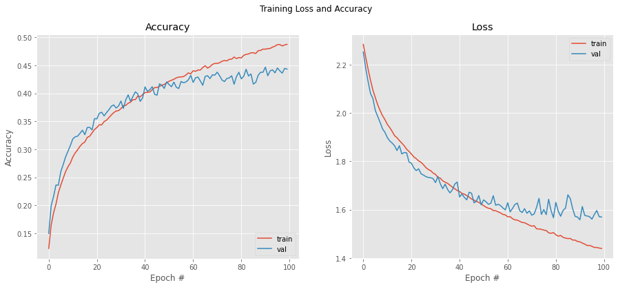

```
----------
Loss: 1.569898
Accuracy: 0.443200
```

```python
# Resultados
plot_prediction(ann_epoch, mfit_ann)

score = model.evaluate(X_test_gflat, y_test, verbose=0)
print ("-"*10)
print ("Loss: %f"%(score[0]))
print ("Accuracy: %f"%(score[1]))
```

## 3. Red Neuronal Convolucional de una capa [2,5 puntos]

A continuación implementaremos una red neuronal convolucional de una capa y realizaremos el entrenamiento y test sobre el dataset CIFAR.

Se recomienda, a partir de este punto realizar el entrenamiento en una máquina con GPU (puede activarse en plataformas como Google Colab o Kaggle) con el fin de reducir los tiempos de entrenamiento.

### 3.1 Pre-procesado de datos

El primer paso para entrenar una red neuronal consiste en pre-procesar los datos de entrenamiento y test para que cuadren con las dimensiones de la entrada de la red neuronal.

**Ejercicio [0,5 pts.]:** Ajustar el tamaño de los datos de entrenamiento y test para que tengan 4 dimensiones (la última dimensión tiene que ser 1 para indicar que las imágenes están en escala de grises).

**Nota**: Utilizar el número de datos de entrenamiento y test y el tamaño de las imágenes.

```python
X_train_grey = X_train_grey.reshape(50000,32,32,1)
X_test_grey = X_test_grey.reshape(10000,32,32,1)
```

### 3.2 Creación del modelo

Se quiere implementar el modelo `Sequential` de Keras con las siguientes características:

- La primera capa que añadiremos será una capa convolucional con las siguientes propiedades:
  - Número de kernels (neuronas) de la primera capa oculta: 64 neuronas
  - Tamaño de los kernels: 3x3
  - Activación de los kernels: ReLU
- A continuación añadiremos una capa Flatten para conectar la salida de la capa convolucional con la entrada de una capa densa.
- Por último, añadiremos una capa densa de salida con el número de neuronas y función de activación adecuadas para llevar a cabo la clasificación.

**Ejercicio [1,5 pts.]:** Construir el modelo según los requerimientos indicados, además:

- Imprime el modelo para ver el número de parámetros a entrenar.
- Compila el modelo con la función de pérdida más adecuada, el optimizador ADAM y la métrica Accuracy.
- Ajusta el modelo con 20 épocas y un tamaño del batch de 128. Mide el tiempo de entrenamiento.
- Muestra las gráficas de accuracy y loss. En cada gráfica debe visualizarse la curva de entrenamiento y la de validación
- Realiza la evaluación del modelo para mostrar la pérdida y la precisión final.

```python
# Crear la CNN monocapa
num_classes = 10
model = Sequential()

# Añadir las capas
model.add(Conv2D(64, kernel_size=3, activation="relu", input_shape=(32,32,1)))
model.add(Flatten())
model.add(Dense(num_classes, activation="softmax"))

print(model.summary())
```

```
Model: "sequential_1"
_________________________________________________________________
 Layer (type)                Output Shape              Param #
=================================================================
 conv2d (Conv2D)             (None, 30, 30, 64)        640

 flatten (Flatten)           (None, 57600)             0

 dense_7 (Dense)             (None, 10)                576010

=================================================================
Total params: 576,650
Trainable params: 576,650
Non-trainable params: 0
_________________________________________________________________
None
```

```python
# Compile
model.compile(optimizer='adam', loss='categorical_crossentropy', metrics=['accuracy'])
```

```python
# Entrenamiento del modelo
n_epochs_onelayer = 20
verbose = 2
t = time.time()
mfit_onelayer = model.fit(X_train_grey, y_train, verbose=verbose,validation_data=(X_test_grey, y_test), batch_size=128, epochs=n_epochs_onelayer)
print ("Tiempo de entrenamiento: ",time.time() - t, "segundos.")
```

```
391/391 - 12s - loss: 1.7150 - accuracy: 0.3994 - val_loss: 1.5299 - val_accuracy: 0.4706 - 12s/epoch - 30ms/step
391/391 - 4s - loss: 1.4320 - accuracy: 0.5079 - val_loss: 1.4914 - val_accuracy: 0.4884 - 4s/epoch - 9ms/step
391/391 - 4s - loss: 1.3281 - accuracy: 0.5475 - val_loss: 1.3739 - val_accuracy: 0.5254 - 4s/epoch - 10ms/step
391/391 - 3s - loss: 1.2391 - accuracy: 0.5804 - val_loss: 1.3275 - val_accuracy: 0.5433 - 3s/epoch - 9ms/step
391/391 - 4s - loss: 1.1734 - accuracy: 0.6026 - val_loss: 1.3600 - val_accuracy: 0.5300 - 4s/epoch - 10ms/step
391/391 - 3s - loss: 1.1177 - accuracy: 0.6230 - val_loss: 1.2847 - val_accuracy: 0.5557 - 3s/epoch - 9ms/step
391/391 - 3s - loss: 1.0665 - accuracy: 0.6391 - val_loss: 1.2907 - val_accuracy: 0.5585 - 3s/epoch - 9ms/step
391/391 - 3s - loss: 1.0211 - accuracy: 0.6562 - val_loss: 1.2559 - val_accuracy: 0.5681 - 3s/epoch - 9ms/step
391/391 - 3s - loss: 0.9827 - accuracy: 0.6693 - val_loss: 1.2544 - val_accuracy: 0.5672 - 3s/epoch - 9ms/step
391/391 - 3s - loss: 0.9397 - accuracy: 0.6846 - val_loss: 1.2342 - val_accuracy: 0.5780 - 3s/epoch - 9ms/step
391/391 - 4s - loss: 0.9063 - accuracy: 0.6943 - val_loss: 1.2621 - val_accuracy: 0.5714 - 4s/epoch - 10ms/step
391/391 - 3s - loss: 0.8690 - accuracy: 0.7089 - val_loss: 1.2802 - val_accuracy: 0.5671 - 3s/epoch - 9ms/step
391/391 - 3s - loss: 0.8387 - accuracy: 0.7195 - val_loss: 1.2491 - val_accuracy: 0.5842 - 3s/epoch - 9ms/step
391/391 - 4s - loss: 0.8089 - accuracy: 0.7310 - val_loss: 1.2408 - val_accuracy: 0.5842 - 4s/epoch - 9ms/step
391/391 - 4s - loss: 0.7828 - accuracy: 0.7392 - val_loss: 1.2553 - val_accuracy: 0.5821 - 4s/epoch - 10ms/step
391/391 - 3s - loss: 0.7501 - accuracy: 0.7527 - val_loss: 1.2464 - val_accuracy: 0.5863 - 3s/epoch - 9ms/step
391/391 - 4s - loss: 0.7263 - accuracy: 0.7574 - val_loss: 1.2625 - val_accuracy: 0.5839 - 4s/epoch - 9ms/step
391/391 - 4s - loss: 0.6996 - accuracy: 0.7695 - val_loss: 1.2740 - val_accuracy: 0.5820 - 4s/epoch - 10ms/step
391/391 - 3s - loss: 0.6745 - accuracy: 0.7805 - val_loss: 1.2824 - val_accuracy: 0.5785 - 3s/epoch - 9ms/step
391/391 - 3s - loss: 0.6501 - accuracy: 0.7881 - val_loss: 1.2723 - val_accuracy: 0.5855 - 3s/epoch - 9ms/step
Tiempo de entrenamiento:  82.71339297294617 segundos.
```

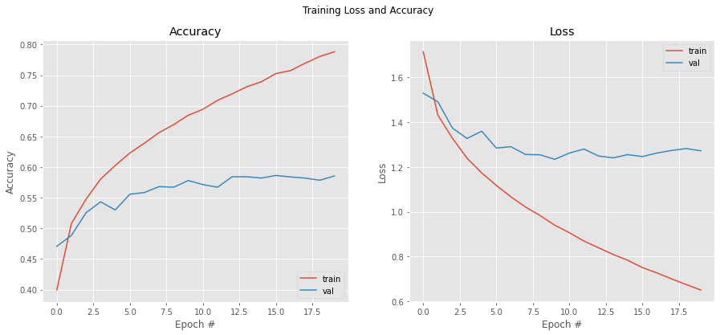

```
----------
Loss: 1.272300
Accuracy: 0.585500
```

```python
# Resultados
plot_prediction(n_epochs_onelayer, mfit_onelayer)
score = model.evaluate(X_test_grey, y_test, verbose=0)
print ("-"*10)
print ("Loss: %f"%(score[0]))
print ("Accuracy: %f"%(score[1]))
```

## 4. Deep CNN con Maxpooling y Dropout [2 puntos]

En el ejercicio anterior hemos implementado una red convolucional de una sola capa. Ahora vamos a implementar una red neuronal convolucional profunda y veremos como esto se traduce en un mejor rendimiento en los resultados.

### 4.1 Creación del modelo

En este caso volveremos a utilizar el modelo `Sequential` de Keras que constará de:

- Dos capas convolucionales de 32 kernels cada una de tamaño 3x3
- Una capa de MaxPooling con un tamaño de 2x2
- Una capa de Dropout con un rate=0.2
- Dos capas convolucionales de 64 kernels cada una de tamaño 3x3
- Una capa de MaxPooling con un tamaño de 2x2
- Una capa de Dropout con un rate=0.2
- Dos capas convolucionales de 128 kernels cada una de tamaño 3x3
- Una capa de MaxPooling con un tamaño de 2x2
- Una capa de Dropout con un rate=0.2
- Todas las capas convolucionales con función de activación ReLU y padding = same
- Una capa Flatten
- Una capa densa con 128 neuronas y función de activación ReLU
- Una capa de Dropout con un rate=0.2
- Una capa densa de salida con el número de neuronas y la función de activación necesarias para llevar a cabo la clasificación

**Ejercicio [1,5 pts.]:** Construir el modelo según los requerimientos indicados, además:

- Imprime el modelo para ver el número de parámetros a entrenar.
- Compila el modelo con la función de pérdida más adecuada, el optimizador SGD (con learning rate de 0.001 y momentum de 0.9) y la métrica Accuracy.
- Ajusta el modelo con 150 épocas y un tamaño del batch de 128. Mide el tiempo de entrenamiento.
- Muestra las gráficas de accuracy y loss. En cada gráfica debe visualizarse la curva de entrenamiento y la de validación
- Realiza la evaluación del modelo para mostrar la pérdida y la precisión final.

```python
# Crear la CNN profunda

model = Sequential()
model.add(Conv2D(32, kernel_size=3, activation='relu', padding='same', input_shape=(32, 32, 1)))
model.add(Conv2D(32, kernel_size=3, activation='relu', padding='same'))
model.add(MaxPooling2D((2, 2)))
model.add(Dropout(0.2))
model.add(Conv2D(64, kernel_size=3, activation='relu', padding='same'))
model.add(Conv2D(64, kernel_size=3, activation='relu', padding='same'))
model.add(MaxPooling2D((2, 2)))
model.add(Dropout(0.2))
model.add(Conv2D(128, kernel_size=3, activation='relu', padding='same'))
model.add(Conv2D(128, kernel_size=3, activation='relu', padding='same'))
model.add(MaxPooling2D((2, 2)))
model.add(Dropout(0.2))
model.add(Flatten())
model.add(Dense(128, activation='relu'))
model.add(Dropout(0.2))
model.add(Dense(10, activation='softmax'))

print(model.summary())
```

```
Model: "sequential_2"
_________________________________________________________________
 Layer (type)                Output Shape              Param #
=================================================================
 conv2d_1 (Conv2D)           (None, 32, 32, 32)        320

 conv2d_2 (Conv2D)           (None, 32, 32, 32)        9248

 max_pooling2d (MaxPooling2D  (None, 16, 16, 32)       0
 )

 dropout_3 (Dropout)         (None, 16, 16, 32)        0

 conv2d_3 (Conv2D)           (None, 16, 16, 64)        18496

 conv2d_4 (Conv2D)           (None, 16, 16, 64)        36928

 max_pooling2d_1 (MaxPooling  (None, 8, 8, 64)         0
 2D)

 dropout_4 (Dropout)         (None, 8, 8, 64)          0

 conv2d_5 (Conv2D)           (None, 8, 8, 128)         73856

 conv2d_6 (Conv2D)           (None, 8, 8, 128)         147584

 max_pooling2d_2 (MaxPooling  (None, 4, 4, 128)        0
 2D)

 dropout_5 (Dropout)         (None, 4, 4, 128)         0

 flatten_1 (Flatten)         (None, 2048)              0

 dense_8 (Dense)             (None, 128)               262272

 dropout_6 (Dropout)         (None, 128)               0

 dense_9 (Dense)             (None, 10)                1290

=================================================================
Total params: 549,994
Trainable params: 549,994
Non-trainable params: 0
_________________________________________________________________
None
```

```python
# Compile
opt = SGD(learning_rate=0.001, momentum=0.9)
model.compile(optimizer=opt, loss='categorical_crossentropy', metrics=['accuracy'])
```

```python
# Entrenamiento del modelo
n_epochs_cnn1 = 150
verbose = 2
t = time.time()
mfit_cnn1 = model.fit(X_train_grey, y_train, verbose=verbose, validation_data=(X_test_grey, y_test), batch_size=128, epochs=n_epochs_cnn1)
print ("Tiempo de entrenamiento: ",time.time() - t, "segundos.")
```

```
391/391 - 13s - loss: 2.2947 - accuracy: 0.1151 - val_loss: 2.2822 - val_accuracy: 0.1447 - 13s/epoch - 34ms/step
391/391 - 11s - loss: 2.2352 - accuracy: 0.1644 - val_loss: 2.1618 - val_accuracy: 0.2403 - 11s/epoch - 29ms/step
391/391 - 12s - loss: 2.1494 - accuracy: 0.2179 - val_loss: 2.1000 - val_accuracy: 0.2641 - 12s/epoch - 31ms/step
391/391 - 12s - loss: 2.0968 - accuracy: 0.2438 - val_loss: 2.0523 - val_accuracy: 0.2745 - 12s/epoch - 29ms/step
391/391 - 12s - loss: 2.0341 - accuracy: 0.2701 - val_loss: 1.9611 - val_accuracy: 0.3029 - 12s/epoch - 29ms/step
391/391 - 11s - loss: 1.9423 - accuracy: 0.3036 - val_loss: 1.8482 - val_accuracy: 0.3418 - 11s/epoch - 29ms/step
391/391 - 11s - loss: 1.8531 - accuracy: 0.3347 - val_loss: 1.7651 - val_accuracy: 0.3675 - 11s/epoch - 29ms/step
391/391 - 12s - loss: 1.7844 - accuracy: 0.3563 - val_loss: 1.7279 - val_accuracy: 0.3783 - 12s/epoch - 30ms/step
391/391 - 11s - loss: 1.7353 - accuracy: 0.3726 - val_loss: 1.6616 - val_accuracy: 0.4022 - 11s/epoch - 29ms/step
391/391 - 12s - loss: 1.6853 - accuracy: 0.3901 - val_loss: 1.5998 - val_accuracy: 0.4268 - 12s/epoch - 31ms/step
391/391 - 12s - loss: 1.6510 - accuracy: 0.4063 - val_loss: 1.5733 - val_accuracy: 0.4335 - 12s/epoch - 29ms/step
391/391 - 12s - loss: 1.6168 - accuracy: 0.4181 - val_loss: 1.5513 - val_accuracy: 0.4425 - 12s/epoch - 29ms/step
391/391 - 11s - loss: 1.5849 - accuracy: 0.4287 - val_loss: 1.5035 - val_accuracy: 0.4635 - 11s/epoch - 29ms/step
391/391 - 12s - loss: 1.5578 - accuracy: 0.4432 - val_loss: 1.4633 - val_accuracy: 0.4772 - 12s/epoch - 31ms/step
391/391 - 12s - loss: 1.5262 - accuracy: 0.4529 - val_loss: 1.4449 - val_accuracy: 0.4854 - 12s/epoch - 31ms/step
391/391 - 12s - loss: 1.4978 - accuracy: 0.4652 - val_loss: 1.4169 - val_accuracy: 0.4981 - 12s/epoch - 31ms/step
391/391 - 12s - loss: 1.4798 - accuracy: 0.4692 - val_loss: 1.3922 - val_accuracy: 0.5068 - 12s/epoch - 31ms/step
391/391 - 12s - loss: 1.4560 - accuracy: 0.4810 - val_loss: 1.3755 - val_accuracy: 0.5102 - 12s/epoch - 29ms/step
391/391 - 12s - loss: 1.4354 - accuracy: 0.4868 - val_loss: 1.3433 - val_accuracy: 0.5236 - 12s/epoch - 30ms/step
391/391 - 12s - loss: 1.4147 - accuracy: 0.4955 - val_loss: 1.3248 - val_accuracy: 0.5291 - 12s/epoch - 30ms/step
391/391 - 12s - loss: 1.3929 - accuracy: 0.5020 - val_loss: 1.3064 - val_accuracy: 0.5378 - 12s/epoch - 29ms/step
391/391 - 12s - loss: 1.3729 - accuracy: 0.5093 - val_loss: 1.3009 - val_accuracy: 0.5371 - 12s/epoch - 29ms/step
391/391 - 12s - loss: 1.3526 - accuracy: 0.5195 - val_loss: 1.3161 - val_accuracy: 0.5321 - 12s/epoch - 29ms/step
391/391 - 11s - loss: 1.3363 - accuracy: 0.5248 - val_loss: 1.2589 - val_accuracy: 0.5552 - 11s/epoch - 29ms/step
391/391 - 12s - loss: 1.3160 - accuracy: 0.5315 - val_loss: 1.2585 - val_accuracy: 0.5508 - 12s/epoch - 30ms/step
391/391 - 11s - loss: 1.2982 - accuracy: 0.5377 - val_loss: 1.2640 - val_accuracy: 0.5515 - 11s/epoch - 29ms/step
391/391 - 12s - loss: 1.2788 - accuracy: 0.5444 - val_loss: 1.2059 - val_accuracy: 0.5743 - 12s/epoch - 31ms/step
391/391 - 11s - loss: 1.2580 - accuracy: 0.5523 - val_loss: 1.2104 - val_accuracy: 0.5699 - 11s/epoch - 29ms/step
391/391 - 12s - loss: 1.2458 - accuracy: 0.5552 - val_loss: 1.2060 - val_accuracy: 0.5679 - 12s/epoch - 31ms/step
391/391 - 11s - loss: 1.2211 - accuracy: 0.5673 - val_loss: 1.1516 - val_accuracy: 0.5906 - 11s/epoch - 29ms/step
391/391 - 12s - loss: 1.2052 - accuracy: 0.5731 - val_loss: 1.1435 - val_accuracy: 0.5957 - 12s/epoch - 31ms/step
391/391 - 11s - loss: 1.1897 - accuracy: 0.5771 - val_loss: 1.1285 - val_accuracy: 0.5984 - 11s/epoch - 29ms/step
391/391 - 12s - loss: 1.1713 - accuracy: 0.5859 - val_loss: 1.1102 - val_accuracy: 0.6079 - 12s/epoch - 29ms/step
391/391 - 11s - loss: 1.1547 - accuracy: 0.5917 - val_loss: 1.1038 - val_accuracy: 0.6108 - 11s/epoch - 29ms/step
391/391 - 11s - loss: 1.1440 - accuracy: 0.5965 - val_loss: 1.1172 - val_accuracy: 0.6089 - 11s/epoch - 29ms/step
391/391 - 12s - loss: 1.1200 - accuracy: 0.6056 - val_loss: 1.0699 - val_accuracy: 0.6252 - 12s/epoch - 31ms/step
391/391 - 12s - loss: 1.1116 - accuracy: 0.6090 - val_loss: 1.0948 - val_accuracy: 0.6144 - 12s/epoch - 30ms/step
391/391 - 12s - loss: 1.0905 - accuracy: 0.6168 - val_loss: 1.0351 - val_accuracy: 0.6410 - 12s/epoch - 30ms/step
391/391 - 13s - loss: 1.0741 - accuracy: 0.6217 - val_loss: 1.0664 - val_accuracy: 0.6271 - 13s/epoch - 32ms/step
391/391 - 12s - loss: 1.0571 - accuracy: 0.6290 - val_loss: 1.0129 - val_accuracy: 0.6476 - 12s/epoch - 30ms/step
```

[output cut: 96 more lines]

```
391/391 - 12s - loss: 0.3608 - accuracy: 0.8704 - val_loss: 0.7113 - val_accuracy: 0.7778 - 12s/epoch - 29ms/step
391/391 - 12s - loss: 0.3547 - accuracy: 0.8740 - val_loss: 0.7125 - val_accuracy: 0.7792 - 12s/epoch - 30ms/step
391/391 - 12s - loss: 0.3570 - accuracy: 0.8727 - val_loss: 0.7002 - val_accuracy: 0.7783 - 12s/epoch - 30ms/step
391/391 - 12s - loss: 0.3524 - accuracy: 0.8749 - val_loss: 0.7156 - val_accuracy: 0.7785 - 12s/epoch - 30ms/step
391/391 - 11s - loss: 0.3488 - accuracy: 0.8753 - val_loss: 0.7248 - val_accuracy: 0.7788 - 11s/epoch - 29ms/step
391/391 - 11s - loss: 0.3438 - accuracy: 0.8780 - val_loss: 0.7126 - val_accuracy: 0.7811 - 11s/epoch - 29ms/step
391/391 - 12s - loss: 0.3428 - accuracy: 0.8778 - val_loss: 0.7050 - val_accuracy: 0.7822 - 12s/epoch - 31ms/step
391/391 - 12s - loss: 0.3338 - accuracy: 0.8792 - val_loss: 0.7203 - val_accuracy: 0.7791 - 12s/epoch - 29ms/step
391/391 - 12s - loss: 0.3338 - accuracy: 0.8792 - val_loss: 0.7247 - val_accuracy: 0.7817 - 12s/epoch - 30ms/step
391/391 - 12s - loss: 0.3290 - accuracy: 0.8821 - val_loss: 0.7201 - val_accuracy: 0.7816 - 12s/epoch - 29ms/step
391/391 - 12s - loss: 0.3276 - accuracy: 0.8814 - val_loss: 0.7154 - val_accuracy: 0.7824 - 12s/epoch - 31ms/step
391/391 - 12s - loss: 0.3242 - accuracy: 0.8842 - val_loss: 0.7391 - val_accuracy: 0.7772 - 12s/epoch - 31ms/step
391/391 - 12s - loss: 0.3167 - accuracy: 0.8859 - val_loss: 0.7098 - val_accuracy: 0.7827 - 12s/epoch - 29ms/step
391/391 - 12s - loss: 0.3170 - accuracy: 0.8856 - val_loss: 0.7171 - val_accuracy: 0.7813 - 12s/epoch - 30ms/step
Tiempo de entrenamiento:  1763.0919239521027 segundos.
```

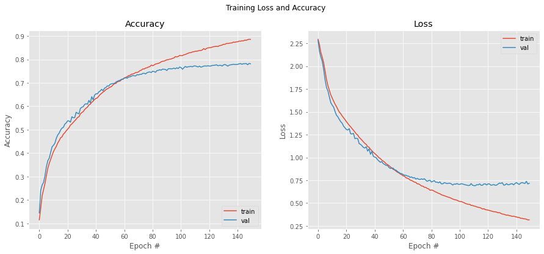

```
----------
Loss: 0.717108
Accuracy: 0.781300
```

```python
# Resultados
plot_prediction(n_epochs_cnn1, mfit_cnn1)

score = model.evaluate(X_test_grey, y_test, verbose=0)
print ("-"*10)
print ("Loss: %f"%(score[0]))
print ("Accuracy: %f"%(score[1]))
```

### 4.2 CNN con imágenes en color

Finalmente vamos a estudiar la influencia del color de las imágenes en la *performance* de la clasificación.

Para ello utilizaremos una red convolucional con la misma estructura de la red del apartado anterior pero cambiando la capa de entrada para que podamos introducir las imágenes originales en color, arrays de dimensión (32, 32, 3).

**Ejercicio [0,5 pts]:** Volver a realizar el ejercicio anterior pero modificando la capa de entrada para poder utilizar el conjunto de datos original, de tamaño (50000, 32, 32, 3) para el conjunto de train y (10000, 32, 32, 3) para el conjunto de test. ¿Influye el color de las imágenes en el resultado de la clasificación? Comentar el resultado.

**Nota**: Recordar normalizar las imágenes para que sus valores estén entre 0 y 1.

```python
# Normalizar
X_train = X_train/255.0
X_test = X_test/255.0
```

```python
v_min = np.min(X_train)
v_max = np.max(X_train)
print("Los valores mínimo y máximo son {} y {}.".format(v_min, v_max))
```

```
Los valores mínimo y máximo son 0.0 y 1.0.
```

```python
# Crear la CNN profunda

model = Sequential()
model.add(Conv2D(32, kernel_size=3, activation='relu', padding='same', input_shape=(32, 32, 3)))
model.add(Conv2D(32, kernel_size=3, activation='relu', padding='same'))
model.add(MaxPooling2D((2, 2)))
model.add(Dropout(0.2))
model.add(Conv2D(64, kernel_size=3, activation='relu', padding='same'))
model.add(Conv2D(64, kernel_size=3, activation='relu', padding='same'))
model.add(MaxPooling2D((2, 2)))
model.add(Dropout(0.2))
model.add(Conv2D(128, kernel_size=3, activation='relu', padding='same'))
model.add(Conv2D(128, kernel_size=3, activation='relu', padding='same'))
model.add(MaxPooling2D((2, 2)))
model.add(Dropout(0.2))
model.add(Flatten())
model.add(Dense(128, activation='relu'))
model.add(Dropout(0.2))
model.add(Dense(10, activation='softmax'))

print(model.summary())
```

```
Model: "sequential_3"
_________________________________________________________________
 Layer (type)                Output Shape              Param #
=================================================================
 conv2d_7 (Conv2D)           (None, 32, 32, 32)        896

 conv2d_8 (Conv2D)           (None, 32, 32, 32)        9248

 max_pooling2d_3 (MaxPooling  (None, 16, 16, 32)       0
 2D)

 dropout_7 (Dropout)         (None, 16, 16, 32)        0

 conv2d_9 (Conv2D)           (None, 16, 16, 64)        18496

 conv2d_10 (Conv2D)          (None, 16, 16, 64)        36928

 max_pooling2d_4 (MaxPooling  (None, 8, 8, 64)         0
 2D)

 dropout_8 (Dropout)         (None, 8, 8, 64)          0

 conv2d_11 (Conv2D)          (None, 8, 8, 128)         73856

 conv2d_12 (Conv2D)          (None, 8, 8, 128)         147584

 max_pooling2d_5 (MaxPooling  (None, 4, 4, 128)        0
 2D)

 dropout_9 (Dropout)         (None, 4, 4, 128)         0

 flatten_2 (Flatten)         (None, 2048)              0

 dense_10 (Dense)            (None, 128)               262272

 dropout_10 (Dropout)        (None, 128)               0

 dense_11 (Dense)            (None, 10)                1290

=================================================================
Total params: 550,570
Trainable params: 550,570
Non-trainable params: 0
_________________________________________________________________
None
```

```python
# Compile
opt = SGD(learning_rate=0.001, momentum=0.9)
model.compile(optimizer=opt, loss='categorical_crossentropy', metrics=['accuracy'])
```

```python
# Entrenamiento del modelo
n_epochs_cnn2 = 150
verbose = 2
t = time.time()
mfit_cnn2 = model.fit(X_train, y_train, verbose=verbose, validation_data=(X_test, y_test), batch_size=128, epochs=n_epochs_cnn2)
print ("Tiempo de entrenamiento: ",time.time() - t, "segundos.")
```

```
391/391 - 14s - loss: 2.2841 - accuracy: 0.1204 - val_loss: 2.2266 - val_accuracy: 0.1978 - 14s/epoch - 36ms/step
391/391 - 13s - loss: 2.0962 - accuracy: 0.2172 - val_loss: 1.9796 - val_accuracy: 0.2865 - 13s/epoch - 32ms/step
391/391 - 12s - loss: 1.9830 - accuracy: 0.2685 - val_loss: 1.9243 - val_accuracy: 0.3069 - 12s/epoch - 30ms/step
391/391 - 12s - loss: 1.9046 - accuracy: 0.3041 - val_loss: 1.7910 - val_accuracy: 0.3609 - 12s/epoch - 31ms/step
391/391 - 12s - loss: 1.8157 - accuracy: 0.3333 - val_loss: 1.7148 - val_accuracy: 0.3825 - 12s/epoch - 30ms/step
391/391 - 12s - loss: 1.7310 - accuracy: 0.3653 - val_loss: 1.6321 - val_accuracy: 0.3990 - 12s/epoch - 31ms/step
391/391 - 12s - loss: 1.6669 - accuracy: 0.3879 - val_loss: 1.5638 - val_accuracy: 0.4276 - 12s/epoch - 30ms/step
391/391 - 12s - loss: 1.6085 - accuracy: 0.4091 - val_loss: 1.5118 - val_accuracy: 0.4492 - 12s/epoch - 30ms/step
391/391 - 12s - loss: 1.5567 - accuracy: 0.4314 - val_loss: 1.4627 - val_accuracy: 0.4662 - 12s/epoch - 30ms/step
391/391 - 12s - loss: 1.5097 - accuracy: 0.4501 - val_loss: 1.4231 - val_accuracy: 0.4862 - 12s/epoch - 30ms/step
391/391 - 12s - loss: 1.4650 - accuracy: 0.4670 - val_loss: 1.3718 - val_accuracy: 0.5025 - 12s/epoch - 30ms/step
391/391 - 12s - loss: 1.4232 - accuracy: 0.4855 - val_loss: 1.3105 - val_accuracy: 0.5292 - 12s/epoch - 30ms/step
391/391 - 12s - loss: 1.3845 - accuracy: 0.5023 - val_loss: 1.2797 - val_accuracy: 0.5403 - 12s/epoch - 31ms/step
391/391 - 12s - loss: 1.3467 - accuracy: 0.5156 - val_loss: 1.2570 - val_accuracy: 0.5515 - 12s/epoch - 30ms/step
391/391 - 12s - loss: 1.3135 - accuracy: 0.5309 - val_loss: 1.2362 - val_accuracy: 0.5630 - 12s/epoch - 31ms/step
391/391 - 12s - loss: 1.2789 - accuracy: 0.5426 - val_loss: 1.2256 - val_accuracy: 0.5637 - 12s/epoch - 30ms/step
391/391 - 12s - loss: 1.2428 - accuracy: 0.5583 - val_loss: 1.1505 - val_accuracy: 0.5951 - 12s/epoch - 31ms/step
391/391 - 12s - loss: 1.2160 - accuracy: 0.5650 - val_loss: 1.1193 - val_accuracy: 0.6038 - 12s/epoch - 30ms/step
391/391 - 12s - loss: 1.1866 - accuracy: 0.5788 - val_loss: 1.0904 - val_accuracy: 0.6131 - 12s/epoch - 30ms/step
391/391 - 12s - loss: 1.1580 - accuracy: 0.5892 - val_loss: 1.0825 - val_accuracy: 0.6158 - 12s/epoch - 30ms/step
391/391 - 12s - loss: 1.1299 - accuracy: 0.5963 - val_loss: 1.0449 - val_accuracy: 0.6300 - 12s/epoch - 30ms/step
391/391 - 12s - loss: 1.1055 - accuracy: 0.6067 - val_loss: 1.0249 - val_accuracy: 0.6418 - 12s/epoch - 30ms/step
391/391 - 12s - loss: 1.0841 - accuracy: 0.6161 - val_loss: 1.0016 - val_accuracy: 0.6489 - 12s/epoch - 30ms/step
391/391 - 12s - loss: 1.0614 - accuracy: 0.6256 - val_loss: 0.9920 - val_accuracy: 0.6466 - 12s/epoch - 31ms/step
391/391 - 12s - loss: 1.0422 - accuracy: 0.6321 - val_loss: 0.9713 - val_accuracy: 0.6545 - 12s/epoch - 30ms/step
391/391 - 12s - loss: 1.0183 - accuracy: 0.6405 - val_loss: 0.9661 - val_accuracy: 0.6603 - 12s/epoch - 30ms/step
391/391 - 12s - loss: 1.0020 - accuracy: 0.6465 - val_loss: 0.9561 - val_accuracy: 0.6623 - 12s/epoch - 30ms/step
391/391 - 12s - loss: 0.9869 - accuracy: 0.6533 - val_loss: 0.9124 - val_accuracy: 0.6811 - 12s/epoch - 30ms/step
391/391 - 12s - loss: 0.9703 - accuracy: 0.6574 - val_loss: 0.9104 - val_accuracy: 0.6797 - 12s/epoch - 30ms/step
391/391 - 12s - loss: 0.9554 - accuracy: 0.6610 - val_loss: 0.9020 - val_accuracy: 0.6835 - 12s/epoch - 30ms/step
391/391 - 12s - loss: 0.9400 - accuracy: 0.6671 - val_loss: 0.8791 - val_accuracy: 0.6876 - 12s/epoch - 30ms/step
391/391 - 12s - loss: 0.9271 - accuracy: 0.6731 - val_loss: 0.8625 - val_accuracy: 0.6959 - 12s/epoch - 30ms/step
391/391 - 12s - loss: 0.9120 - accuracy: 0.6778 - val_loss: 0.8583 - val_accuracy: 0.6994 - 12s/epoch - 30ms/step
391/391 - 12s - loss: 0.9020 - accuracy: 0.6817 - val_loss: 0.8413 - val_accuracy: 0.7035 - 12s/epoch - 30ms/step
391/391 - 12s - loss: 0.8875 - accuracy: 0.6855 - val_loss: 0.8375 - val_accuracy: 0.7058 - 12s/epoch - 30ms/step
391/391 - 12s - loss: 0.8772 - accuracy: 0.6883 - val_loss: 0.8316 - val_accuracy: 0.7065 - 12s/epoch - 30ms/step
391/391 - 12s - loss: 0.8676 - accuracy: 0.6933 - val_loss: 0.8481 - val_accuracy: 0.6996 - 12s/epoch - 30ms/step
391/391 - 12s - loss: 0.8572 - accuracy: 0.6958 - val_loss: 0.8061 - val_accuracy: 0.7162 - 12s/epoch - 31ms/step
391/391 - 12s - loss: 0.8454 - accuracy: 0.6993 - val_loss: 0.8073 - val_accuracy: 0.7185 - 12s/epoch - 30ms/step
391/391 - 12s - loss: 0.8345 - accuracy: 0.7067 - val_loss: 0.7993 - val_accuracy: 0.7181 - 12s/epoch - 31ms/step
```

[output cut: 96 more lines]

```
391/391 - 12s - loss: 0.3096 - accuracy: 0.8887 - val_loss: 0.6138 - val_accuracy: 0.8098 - 12s/epoch - 30ms/step
391/391 - 12s - loss: 0.3077 - accuracy: 0.8885 - val_loss: 0.6073 - val_accuracy: 0.8084 - 12s/epoch - 31ms/step
391/391 - 12s - loss: 0.3010 - accuracy: 0.8916 - val_loss: 0.6314 - val_accuracy: 0.8071 - 12s/epoch - 30ms/step
391/391 - 12s - loss: 0.3021 - accuracy: 0.8913 - val_loss: 0.6255 - val_accuracy: 0.8091 - 12s/epoch - 30ms/step
391/391 - 12s - loss: 0.2949 - accuracy: 0.8943 - val_loss: 0.6399 - val_accuracy: 0.8066 - 12s/epoch - 30ms/step
391/391 - 12s - loss: 0.2929 - accuracy: 0.8932 - val_loss: 0.6294 - val_accuracy: 0.8072 - 12s/epoch - 30ms/step
391/391 - 12s - loss: 0.2928 - accuracy: 0.8954 - val_loss: 0.6391 - val_accuracy: 0.8093 - 12s/epoch - 30ms/step
391/391 - 12s - loss: 0.2930 - accuracy: 0.8943 - val_loss: 0.6394 - val_accuracy: 0.8045 - 12s/epoch - 31ms/step
391/391 - 12s - loss: 0.2818 - accuracy: 0.8975 - val_loss: 0.6354 - val_accuracy: 0.8088 - 12s/epoch - 30ms/step
391/391 - 12s - loss: 0.2829 - accuracy: 0.9004 - val_loss: 0.6238 - val_accuracy: 0.8090 - 12s/epoch - 31ms/step
391/391 - 12s - loss: 0.2790 - accuracy: 0.8983 - val_loss: 0.6276 - val_accuracy: 0.8085 - 12s/epoch - 30ms/step
391/391 - 12s - loss: 0.2778 - accuracy: 0.9001 - val_loss: 0.6250 - val_accuracy: 0.8090 - 12s/epoch - 31ms/step
391/391 - 12s - loss: 0.2784 - accuracy: 0.8996 - val_loss: 0.6384 - val_accuracy: 0.8060 - 12s/epoch - 30ms/step
391/391 - 12s - loss: 0.2708 - accuracy: 0.9015 - val_loss: 0.6487 - val_accuracy: 0.8095 - 12s/epoch - 30ms/step
Tiempo de entrenamiento:  1823.9130203723907 segundos.
```

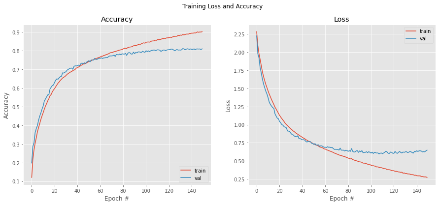

```
----------
Loss: 0.648654
Accuracy: 0.809500
```

```python
# Resultados
plot_prediction(n_epochs_cnn2, mfit_cnn2)

score = model.evaluate(X_test, y_test, verbose=0)
print ("-"*10)
print ("Loss: %f"%(score[0]))
print ("Accuracy: %f"%(score[1]))
```

## 5. Comparativa de los modelos implementados y predicción [1,5 puntos]

En este último apartado compararemos los modelos implementados y realizaremos la clasificación de algunas imágenes con el modelo que ha dado los mejores resultados.

### 5.1 Comparativa de los modelos implementados

**Ejercicio [0,5 pts.]:** Realizar una comparativa de los modelos implementados comentando: * La precisión obtenida * La pérdida * El tiempo de entrenamiento * El número de parámetros a entrenar Comentar los resultados obtenidos. En base a los resultados obtenidos ¿Qué modelo seleccionaríais como el mejor?

### 5.2 Análisis de la mejor solución

**Ejercicio [0,5 pts.]:** Realizar un análisis de las medidas estadísticas más relevantes del modelo seleccionado en el apartado anterior y representar su matriz de confusión.

¿Qué clase es la que mejor se predice? ¿Y la que peor resultados obtiene?

Comentar los resultados

```python
# Realizamos la predicción de todo el conjunto de test
pred = model.predict(X_test)
# Deshacer el one-hot encoding
y_pred = np.argmax(pred, axis=1)
y_test_int = np.argmax(y_test, axis=1)

# Imprimimos el informe sobre la clasificación

print(classification_report(y_test_int, y_pred))
```

```
              precision    recall  f1-score   support

           0       0.84      0.84      0.84      1000
           1       0.89      0.92      0.91      1000
           2       0.78      0.70      0.74      1000
           3       0.67      0.60      0.64      1000
           4       0.74      0.83      0.78      1000
           5       0.66      0.79      0.72      1000
           6       0.85      0.85      0.85      1000
           7       0.87      0.84      0.85      1000
           8       0.93      0.87      0.90      1000
           9       0.89      0.86      0.88      1000

    accuracy                           0.81     10000
   macro avg       0.81      0.81      0.81     10000
weighted avg       0.81      0.81      0.81     10000
```

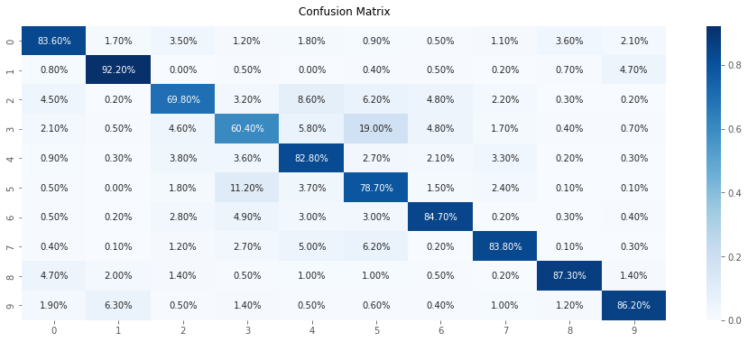

```python
#Matriz de confusión
conf_mat = confusion_matrix(y_test_int, y_pred)
v_min = np.min(conf_mat)
v_max = np.max(conf_mat)
plt.figure(figsize=(16, 6))
heatmap = sns.heatmap(conf_mat/np.sum(conf_mat[0]), annot=True,
            fmt='.2%', cmap='Blues') #valores de correlación
heatmap.set_title('Confusion Matrix', fontdict={'fontsize':12}, pad=12);
```

### 5.3 Predicción de algunas imágenes del conjunto de test

**Ejercicio [0,5 pts.]:** Visualizar diez imágenes al azar del conjunto de test. Mostrar la etiqueta real y la predicción.

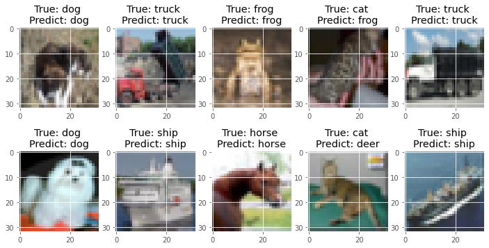

```python
# Seleccionamos al azar 10 imágenes del conjunto de test
n_images = 10
idx_images = np.random.randint(X_test.shape[0], size=n_images)

y_test_int = np.argmax(y_test, axis=1)
images = np.stack([X_test[i] for i in idx_images])

# Realizamos la predicción de las imágenes
pred = model(images)

pred_int = np.argmax(pred, axis=1)

# Visualización de las imágenes predichas
n_rows = 2
n_cols = 5
fig, axes = plt.subplots(ncols=n_cols, nrows=n_rows, figsize=(12,6))
index = 0
for i in range(n_rows):
    for j in range(n_cols):
        axes[i,j].set_title("True: %s \nPredict: %s" % (labels[y_test_int[idx_images[index]]], labels[pred_int[index]]))
        axes[i,j].imshow(images[index])
        index += 1
plt.show()
```